# Forecasting Salmon Runs: A Time Series Analysis of Willamette Falls Fish Ladder Data

Author

Zoe Zhou

Published

March 16, 2025

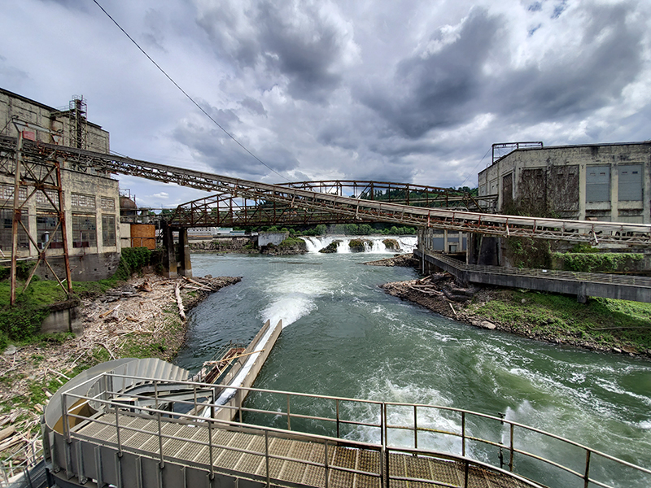

Willamette River Fish Bypass, Photo Credit: Portland General Electric

### Overview

The goal of this analysis is to visualize time series data of fish passage at the Willamette Falls fish ladder to identify trends, seasonal patterns, and annual variations in fish passage. Additionally, the analysis includes forecasting using the Holt-Winters method to predict future trends in salmon runs, providing critical information for watershed management and fish recovery efforts.

#### Background

Fish passage at Willamette Falls is critical for the survival of Oregon’s wild salmon and steelhead, which are on the brink of extinction due to dams blocking access to spawning habitats and degrading river ecosystems. With populations at just 1–2% of their historic levels, this analysis helps uncover migration trends and forecast future passage, providing valuable insights to guide recovery efforts, improve watershed management, and ensure these iconic species are protected for future generations.

#### Data Summary

This project explores adult fish passage data recorded at the Willamette Falls fish ladder on the Willamett River, Oregon from 2001 to 2010. The dataset provides valuable insights into the migration patterns of five salmon species: Chinook, Jack Chinook, Steelhead, Coho, and Jack Coho.

**Data Citation**:

U.S. Army Corps of Engineers, NWD, et al. *DART Adult Passage Counts Daily for All Species*. Data accessed via [Columbia River DART (Data Access in Real Time)](https://www.cbr.washington.edu/dart/query/adult_proj_sum) on January 25, 2023.

#### Analysis Outline

1. Exploratory Data Analysis
2. Data Preprocessing
3. Visualization of Time Series
4. Visualization of Seasonplots for each species
5. Plot Annual Totals for Fish Passage
6. Apply Holt-Winters Forecasting
7. Summarize Trends and Patterns

### Set Up

The following libraries will be used for data manipulation, visualization, and building regression models.

```r
library(tidyverse)
library(here)
library(lubridate)
library(tsibble)
library(feasts)
library(fable)
library(kableExtra)
library(patchwork)
library(skimr)
```

Import data, replace NaN with zero, convert Date column from character to `data` and convert df to tsibble using the `as_tsibble()` function.

```r
# Import data
fish_df <- read_csv(here('data', 'willamette_fish_passage.csv')) %>%
  replace(is.na(.),0) %>%
  janitor::clean_names()

# Convert to ts
fish_ts <- fish_df %>%
  mutate(date = mdy(date)) %>%
  as_tsibble(key = NULL,
             index = date) %>%
  replace(is.na(.), 0)
```

Conduct preliminary data exploration

**Click here to expand summary table**

```r
skim(fish_df)
```

Data summary

| Name | fish_df |
| --- | --- |
| Number of rows | 3652 |
| Number of columns | 16 |
| _______________________ |  |
| Column type frequency: |  |
| character | 2 |
| numeric | 14 |
| ________________________ |  |
| Group variables | None |

**Variable type: character**

| skim_variable | n_missing | complete_rate | min | max | empty | n_unique | whitespace |
| --- | --- | --- | --- | --- | --- | --- | --- |
| project | 0 | 1 | 16 | 16 | 0 | 1 | 0 |
| date | 0 | 1 | 6 | 8 | 0 | 3652 | 0 |

**Variable type: numeric**

| skim_variable | n_missing | complete_rate | mean | sd | p0 | p25 | p50 | p75 | p100 | hist |
| --- | --- | --- | --- | --- | --- | --- | --- | --- | --- | --- |
| chinook_run | 0 | 1 | 0.00 | 0.00 | 0 | 0 | 0.0 | 0.0 | 0.0 | ▁▁▇▁▁ |
| chinook | 0 | 1 | 144.65 | 382.65 | 0 | 0 | 3.0 | 65.0 | 3883.0 | ▇▁▁▁▁ |
| jack_chinook | 0 | 1 | 3.75 | 10.84 | 0 | 0 | 0.0 | 2.0 | 170.0 | ▇▁▁▁▁ |
| steelhead | 0 | 1 | 81.19 | 114.13 | -2 | 6 | 23.0 | 119.0 | 709.0 | ▇▂▁▁▁ |
| wild_steelhead | 0 | 1 | 0.00 | 0.00 | 0 | 0 | 0.0 | 0.0 | 0.0 | ▁▁▇▁▁ |
| sockeye | 0 | 1 | 0.00 | 0.00 | 0 | 0 | 0.0 | 0.0 | 0.0 | ▁▁▇▁▁ |
| coho | 0 | 1 | 19.94 | 88.88 | -2 | 0 | 0.0 | 1.0 | 1290.0 | ▇▁▁▁▁ |
| jack_coho | 0 | 1 | 3.92 | 17.96 | 0 | 0 | 0.0 | 0.0 | 380.0 | ▇▁▁▁▁ |
| shad | 0 | 1 | 0.00 | 0.00 | 0 | 0 | 0.0 | 0.0 | 0.0 | ▁▁▇▁▁ |
| lamprey | 0 | 1 | 0.00 | 0.00 | 0 | 0 | 0.0 | 0.0 | 0.0 | ▁▁▇▁▁ |
| bull_trout | 0 | 1 | 0.00 | 0.00 | 0 | 0 | 0.0 | 0.0 | 0.0 | ▁▁▇▁▁ |
| chum | 0 | 1 | 0.00 | 0.00 | 0 | 0 | 0.0 | 0.0 | 0.0 | ▁▁▇▁▁ |
| pink | 0 | 1 | 0.00 | 0.00 | 0 | 0 | 0.0 | 0.0 | 0.0 | ▁▁▇▁▁ |
| temp_c | 0 | 1 | 8.04 | 7.88 | 0 | 0 | 7.2 | 14.4 | 26.7 | ▇▅▂▂▂ |

### Data Visualization

**Daily Time Series Plot**

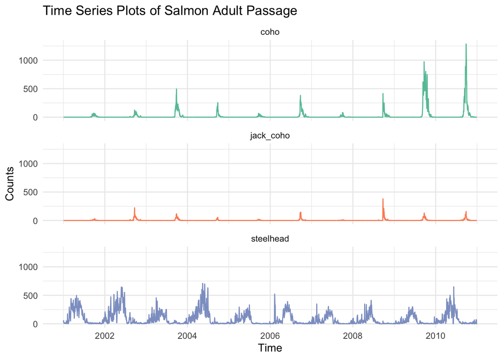

Figure 1: Time Series of Adult Passage for Coho, Jack Coho, and Steelhead salmon.

```r
# Prepare data for plotting
fish_long <- fish_ts %>%
  janitor::clean_names() %>%
  select('date', 'steelhead','coho', 'jack_coho') %>%
  pivot_longer(
    cols = -date,
    names_to = "species",
    values_to = "counts"
  )

# Create plot
ggplot(fish_long, aes(x=date, y=counts, color=species)) +
  geom_line() +
  labs(title = "Time Series Plots of Salmon Adult Passage",
       x = "Time",
       y = "Counts") +
  scale_color_brewer(palette = "Set2")+
  theme_minimal()+
  facet_wrap(~species,ncol=1)+
  theme(legend.position='none')
```

**Seasonplots**

A seasonplot can help point out seasonal patterns, and help to glean insights over the years. We’ll use `feasts::gg_season()` to create an exploratory seasonplot, which has month on the x-axis, salmon counts on the y-axis, and each year is its own series (mapped by line color).

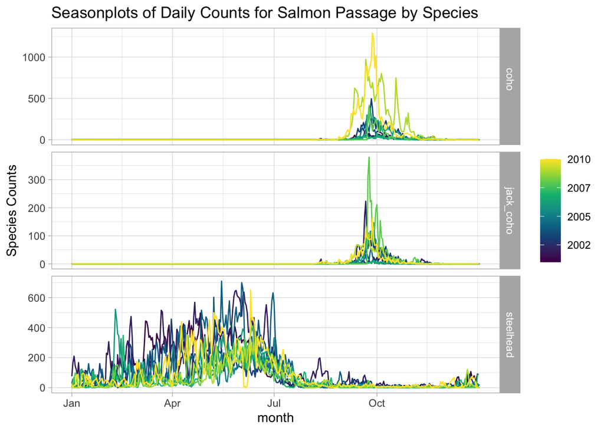

Figure 2: Seasonplots of Daily Counts for Salmon Passage by Species

```r
fish_long %>%
  gg_season(y=counts, pal=hcl.colors(n=10)) +
  theme_light()+
  labs(title='Seasonplots of Daily Counts for Salmon Passage by Species',
    x="month",
       y="Species Counts")
```

Figure 2 displays the seasonal variation in the counts of salmon species across all years, with each line representing a specific year and highlighting recurring monthly patterns. Since the daily counts were too stochastic and busy, especially for steelhead salmon, I opted to use monthly means for clearer interpretation.

Seasonplots with monthly means:

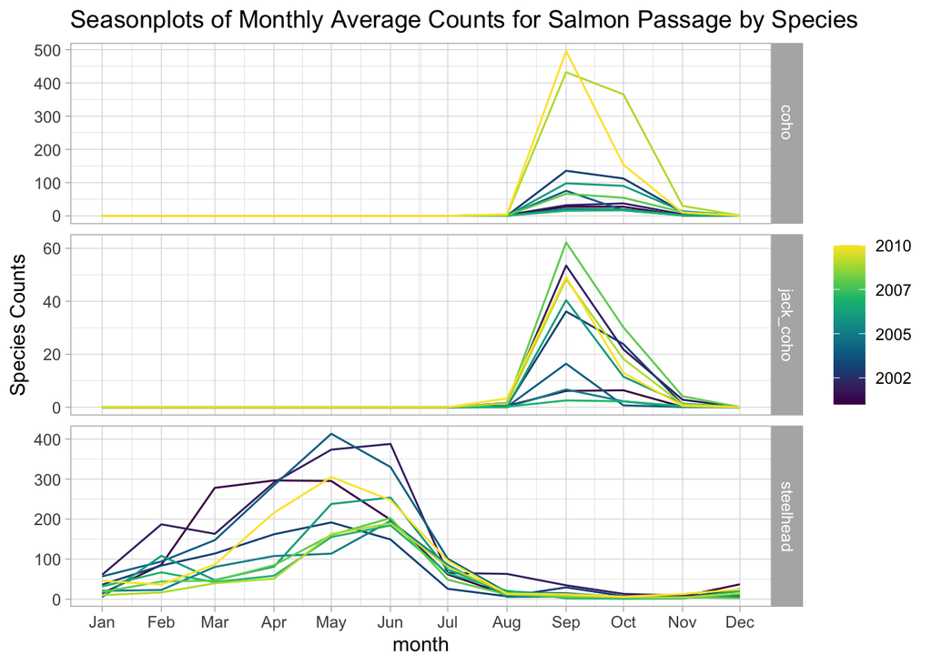

Figure 3: Seasonplots of Monthly Average Counts for Salmon Passage by Species

```r
fish_month <- fish_long %>%
  index_by(yr_mo = ~yearmonth(.)) %>%
  group_by(species) %>%
  summarize(month_mean = mean(counts, na.rm=TRUE)) %>%
  ungroup()

#fish_month
fish_month %>%
  gg_season(y=month_mean, pal=hcl.colors(n=10)) +
  theme_light()+
  labs(title='Seasonplots of Monthly Average Counts for Salmon Passage by Species',
       x="month",
       y="Species Counts")
```

**Annual Counts**

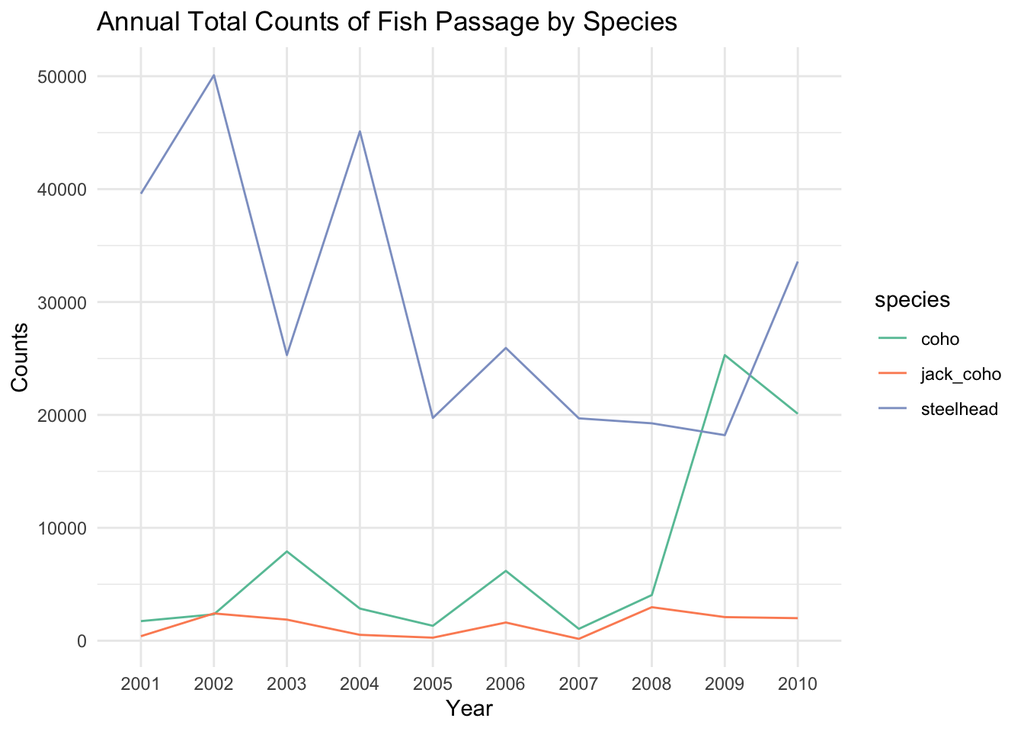

Figure 4: Plot of Annual Counts of Fish Passage by Species

```r
# Prep data for plotting
fish_yr <- fish_long %>%
  index_by(year = ~year(.)) %>%
  group_by(species) %>%
  summarize(annual_total = sum(counts)) %>%
  ungroup()
# Convert year column to factor
fish_yr$year = as.factor(fish_yr$year)

fish_yr %>%
  ggplot(aes(x = year, y = annual_total, color = species, group = species)) +  # Explicitly group by species
  geom_line() +
  theme_minimal() +
  labs(
    title = "Annual Total Counts of Fish Passage by Species",
    x = "Year",
    y = "Counts"
  ) +
  scale_color_brewer(palette = 'Set2')
```